# Fully GAN Image Captioner

## Introduction

We peresnt an image captioner model completely base on original GAN.This model doesn't need policy gradient for learning and it uses original cost function. we test our model on a simple dataset which is explained later.If you are familliar with GAN models, you know that it consists two networks: Generator and Discriminator. Generator needs a noise vector to map that to pictures or word2vec matrixes like here. we uses output of an encoder with size of 10 for that and generate matrixes.lets look at the overall diagram for better understanding

[figure not shown]

## Steps

We devide our work into these steps

1. Create Encoder
2. Build Word2vec Model
3. Create Generator & Discriminator
4. Train The Model
5. Inference and Results

Work is started with importing neseccary modules and configuration

```python
import torch
import numpy as np
import pandas as pd
from torch.utils.data import Dataset, DataLoader
import torchvision
import os
import matplotlib.pyplot as plt
from PIL import Image
from gensim.models import Word2Vec,FastText
from tqdm import tqdm
import random

import warnings
warnings.filterwarnings('ignore')
```

```python
torch.backends.cudnn.deterministic = True
torch.set_default_tensor_type('torch.DoubleTensor')
device = torch.device("cuda" if torch.cuda.is_available() else "cpu")
```

We create a custom dataset for our work based on PyTorch Dataset class

```python
class dataset(Dataset):

    def __init__(self, csv_file, root_dir):
        """
        Args:
            csv_file (string): Path to the csv file with annotations.
            root_dir (string): Directory with all the images.
        """

        self.caption_file = pd.read_csv(csv_file,header=None)
        self.root_dir = root_dir

    def __len__(self):
        return len(self.caption_file)

    def __getitem__(self, idx):
        img_name = os.path.join(self.root_dir,self.caption_file.iloc[idx, 0])
        image = Image.open(img_name)
        image = torchvision.transforms.functional.to_grayscale(image, num_output_channels=1)    #RGB -> GrayScale
        image = np.array(image,dtype=np.float)
        image = torch.from_numpy(image)
        image = (image.max()-image)/(image.max()-image.min()) #normalize
        caption = self.caption_file.iloc[idx, 1]
        sample = image,caption


        return sample
```

After that the dataloader is created. we use all of our dataset in one batch (batchSize = 54) because it is small and simple dataset

```python
dataset_ = dataset("Train\Train.csv","Train")
dataloader = DataLoader(dataset_, batch_size=54,shuffle=True)
```

```python
image , cap = next(iter(dataloader))

print("shape of image is {0}".format(image.shape))
print("shape of caption is {0}".format(len(cap)))
```

```
shape of image is torch.Size([54, 100, 100])
shape of caption is 54
```

Now lets take a look at some datapoints of the dataset:

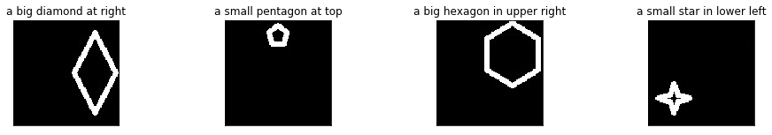

```python
fig, ax = plt.subplots(1, 4, figsize=(15, 30))


for _ in range(4):
    ax[_].imshow(image[_],cmap=plt.cm.gray)
    ax[_].set_xticks([])
    ax[_].set_yticks([])
    ax[_].set_title(cap[_])

fig.subplots_adjust(wspace=1, hspace=1)
plt.show()
```

### Create Encoder

our Encoder is a simple autoencoder with 4 layers

[figure not shown]

```python
class Flatten(torch.nn.Module):
    def forward(self, x):
        batchSize = x.shape[0]
        return x.view(batchSize, -1)

flatten = Flatten() #For Flatten images and Tensors


class EncoderDecoder(torch.nn.Module):
    def __init__(self):
        '''
        MLP Encoder-Decoder for encoding images
        it receives 100*100 images, down-sample them to 10 dim vectors
        then trys to reconstruct to what they really were.
        '''
        super().__init__()

        self.encode = torch.nn.Sequential(
                flatten,
                torch.nn.Linear(100*100,1000),
                torch.nn.ReLU(inplace=True),
                torch.nn.Linear(1000,500),
                torch.nn.ReLU(inplace=True),
                torch.nn.Linear(500,100),
                torch.nn.ReLU(inplace=True),
                torch.nn.Linear(100,10),
                torch.nn.ReLU(inplace=True)
                )
        self.decode = torch.nn.Sequential(
                torch.nn.Linear(10,100),
                torch.nn.ReLU(inplace=True),
                torch.nn.Linear(100,500),
                torch.nn.ReLU(inplace=True),
                torch.nn.Linear(500,1000),
                torch.nn.ReLU(inplace=True),
                torch.nn.Linear(1000,100*100),
                torch.nn.ReLU()
                )

    def forward(self,input):
        batchSize = input.size()[0]
        input = input.to(device)
        input = self.encode(input)
        return self.decode(input).view(batchSize,100,100)
```

As you can see the code layer is 10 dim

```python
encoderdecoder=EncoderDecoder()
criterion =  torch.nn.MSELoss()
ed_optimizer = torch.optim.Adam(encoderdecoder.parameters(), lr=1e-3, weight_decay=1e-5)
criterion.to(device)
encoderdecoder.to(device)
```

```
EncoderDecoder(
  (encode): Sequential(
    (0): Flatten()
    (1): Linear(in_features=10000, out_features=1000, bias=True)
    (2): ReLU(inplace=True)
    (3): Linear(in_features=1000, out_features=500, bias=True)
    (4): ReLU(inplace=True)
    (5): Linear(in_features=500, out_features=100, bias=True)
    (6): ReLU(inplace=True)
    (7): Linear(in_features=100, out_features=10, bias=True)
    (8): ReLU(inplace=True)
  )
  (decode): Sequential(
    (0): Linear(in_features=10, out_features=100, bias=True)
    (1): ReLU(inplace=True)
    (2): Linear(in_features=100, out_features=500, bias=True)
    (3): ReLU(inplace=True)
    (4): Linear(in_features=500, out_features=1000, bias=True)
    (5): ReLU(inplace=True)
    (6): Linear(in_features=1000, out_features=10000, bias=True)
    (7): ReLU()
  )
)
```

```
loss --> 0.05592970522199001 in epoch 1
```

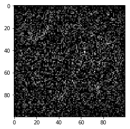

```
loss --> 0.0553103134681123 in epoch 2
loss --> 0.05467966524449274 in epoch 3
loss --> 0.05451416856577453 in epoch 4
loss --> 0.05442721400187612 in epoch 5
loss --> 0.05414250178161291 in epoch 6
loss --> 0.05389042749281251 in epoch 7
loss --> 0.05358238696418209 in epoch 8
loss --> 0.05346880499621708 in epoch 9
loss --> 0.05307135169525213 in epoch 10
loss --> 0.05285025587737314 in epoch 11
```

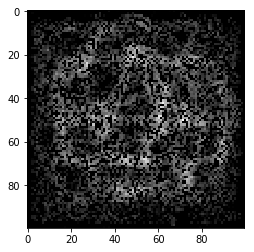

```
loss --> 0.05258951832839338 in epoch 12
loss --> 0.05258521572702405 in epoch 13
loss --> 0.05233506193723909 in epoch 14
loss --> 0.05231305548675322 in epoch 15
loss --> 0.0520771249538617 in epoch 16
loss --> 0.05205543019010344 in epoch 17
loss --> 0.051768637901765606 in epoch 18
loss --> 0.0516538689405533 in epoch 19
loss --> 0.05144197806239635 in epoch 20
loss --> 0.05126778887396459 in epoch 21
```

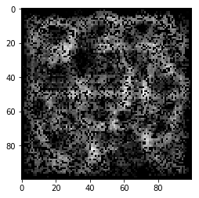

```
loss --> 0.051081737273003 in epoch 22
loss --> 0.05091273717984514 in epoch 23
loss --> 0.0507423563335441 in epoch 24
loss --> 0.05058478593590573 in epoch 25
loss --> 0.05037357012205378 in epoch 26
loss --> 0.05019594549101622 in epoch 27
loss --> 0.04992732861436207 in epoch 28
loss --> 0.04973712109143316 in epoch 29
loss --> 0.04951031414040586 in epoch 30
loss --> 0.049244230781428575 in epoch 31
```

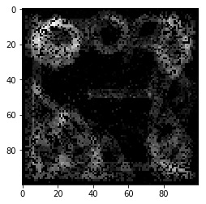

```
loss --> 0.049009558942668924 in epoch 32
loss --> 0.04885924816870603 in epoch 33
loss --> 0.04891858767317183 in epoch 34
loss --> 0.04838026994539252 in epoch 35
loss --> 0.047895695077805216 in epoch 36
loss --> 0.04766240407079951 in epoch 37
loss --> 0.04686869724909908 in epoch 38
loss --> 0.04645567988186732 in epoch 39
loss --> 0.04554596303561746 in epoch 40
loss --> 0.04470081777336453 in epoch 41
```

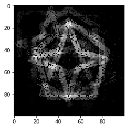

```
loss --> 0.04435796686641694 in epoch 42
loss --> 0.043510663075936276 in epoch 43
loss --> 0.04284636155603531 in epoch 44
loss --> 0.04225019239319562 in epoch 45
loss --> 0.04128186989912066 in epoch 46
loss --> 0.04068829493662306 in epoch 47
loss --> 0.0397380693447552 in epoch 48
loss --> 0.039015032576006387 in epoch 49
loss --> 0.03907297432508769 in epoch 50
loss --> 0.03746094312835123 in epoch 51
```

[figure not shown]

```
loss --> 0.03699580804327261 in epoch 52
loss --> 0.035050992739131474 in epoch 53
loss --> 0.0349983277390274 in epoch 54
loss --> 0.033076949703192644 in epoch 55
loss --> 0.03297545296808435 in epoch 56
loss --> 0.03141513273719937 in epoch 57
loss --> 0.030948091329836388 in epoch 58
loss --> 0.029364779760949016 in epoch 59
loss --> 0.02900489261141833 in epoch 60
loss --> 0.028850207824711788 in epoch 61
```

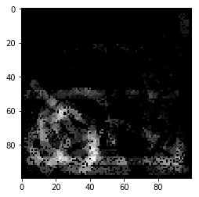

```
loss --> 0.029596827473375106 in epoch 62
loss --> 0.025888967972956246 in epoch 63
loss --> 0.026855589654999647 in epoch 64
loss --> 0.025357099373121254 in epoch 65
loss --> 0.024442383938442443 in epoch 66
loss --> 0.023655587845930293 in epoch 67
loss --> 0.02264281817252754 in epoch 68
loss --> 0.022159806719082707 in epoch 69
loss --> 0.02107960115778097 in epoch 70
loss --> 0.02046358149783557 in epoch 71
```

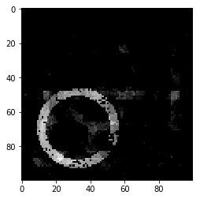

```
loss --> 0.01988776157812975 in epoch 72
loss --> 0.018963875269871873 in epoch 73
loss --> 0.018384260449212222 in epoch 74
loss --> 0.01775964144860655 in epoch 75
loss --> 0.016895096713399806 in epoch 76
loss --> 0.016494521819821743 in epoch 77
loss --> 0.01637210397380946 in epoch 78
loss --> 0.017316418776221136 in epoch 79
loss --> 0.020604555855043588 in epoch 80
loss --> 0.016685132679937067 in epoch 81
```

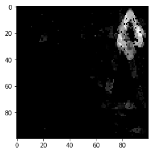

```
loss --> 0.016550172089594296 in epoch 82
loss --> 0.015112624661387358 in epoch 83
loss --> 0.01566100166099105 in epoch 84
loss --> 0.013678206722134106 in epoch 85
loss --> 0.014558111652382211 in epoch 86
loss --> 0.012939733221160701 in epoch 87
loss --> 0.013020589865541997 in epoch 88
loss --> 0.012417290678772609 in epoch 89
loss --> 0.011862542252543464 in epoch 90
loss --> 0.011463500211781654 in epoch 91
```

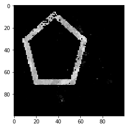

```
loss --> 0.01102915579499584 in epoch 92
loss --> 0.01074301037352803 in epoch 93
loss --> 0.010160304079850689 in epoch 94
loss --> 0.009949453925980819 in epoch 95
loss --> 0.009515127284094276 in epoch 96
loss --> 0.00916998275001567 in epoch 97
loss --> 0.008971348699902149 in epoch 98
loss --> 0.008635857831543579 in epoch 99
loss --> 0.008489815508472052 in epoch 100
loss --> 0.008433115916144963 in epoch 101
```

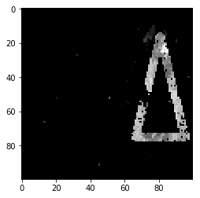

```
loss --> 0.008895481843441888 in epoch 102
loss --> 0.00911029546861753 in epoch 103
loss --> 0.008420262743731088 in epoch 104
loss --> 0.00750426903130492 in epoch 105
loss --> 0.008075295516970855 in epoch 106
loss --> 0.007435456641101607 in epoch 107
loss --> 0.007296222009608993 in epoch 108
loss --> 0.007216542074173054 in epoch 109
loss --> 0.006804594282506697 in epoch 110
loss --> 0.006925850550514569 in epoch 111
```

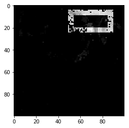

```
loss --> 0.006524744007957017 in epoch 112
loss --> 0.006574789721806289 in epoch 113
loss --> 0.006395881033305709 in epoch 114
loss --> 0.0062366454032595185 in epoch 115
loss --> 0.006180662489812229 in epoch 116
loss --> 0.0059545642086520825 in epoch 117
loss --> 0.0059521487200044935 in epoch 118
loss --> 0.005837554890895319 in epoch 119
loss --> 0.005761224683327757 in epoch 120
loss --> 0.005726471649358964 in epoch 121
```

[11 more figures not shown]

```
loss --> 0.004527634608985241 in epoch 222
loss --> 0.004514533624080255 in epoch 223
loss --> 0.004516347512268326 in epoch 224
loss --> 0.0044875647491782475 in epoch 225
```

```python
for epoch in range(600):
    for image , _ in dataloader:
        computed = encoderdecoder(image)
        loss = criterion(computed,image.to(device))
        ed_optimizer.zero_grad()
        loss.backward()
        ed_optimizer.step()



        print("loss --> {0} in epoch {1}".format(loss.mean().item(),1+epoch))
        if epoch % 10 == 0:

            tmp = image[10]
            tmp = tmp.numpy()
            tmp=tmp.reshape(1,100,100)
            tmp = torch.from_numpy(tmp)

            with torch.no_grad():
                img = encoderdecoder(tmp)
                img = img.cpu().reshape(100,100)
                plt.imshow(img,cmap=plt.cm.gray)
                plt.show()

    if loss.mean().item() < 0.0045:#this number is feature engineered
        break
```

Now we delete the decode part of the autoencoder since we only need the encoder part of it and set it to evaluation mode for infrence use only

```python
encoder = encoderdecoder.encode #delete decode part
del encoderdecoder

for param in encoder.parameters():
    param.requires_grad = False
```

```python
encoder.eval()
```

```
Sequential(
  (0): Flatten()
  (1): Linear(in_features=10000, out_features=1000, bias=True)
  (2): ReLU(inplace=True)
  (3): Linear(in_features=1000, out_features=500, bias=True)
  (4): ReLU(inplace=True)
  (5): Linear(in_features=500, out_features=100, bias=True)
  (6): ReLU(inplace=True)
  (7): Linear(in_features=100, out_features=10, bias=True)
  (8): ReLU(inplace=True)
)
```

### Build Word2vec model

we use word2vec as intermediaries for generating caption this can be replace by other embedding like FastText or GloVe but in this model, Word2Vec has the best result

it starts with padding captions to make them same size and build vocabulary </ p>

```python
padded_captions=[]
for _ in cap :
    lentgh = len(_.split())

    if lentgh < 7:
        for i in range(7-lentgh):
            _ = _ +" <e>"

    padded_captions.append(_)
```

```python
padded_captions
```

```
['a big diamond at right <e> <e>',
 'a small pentagon at top <e> <e>',
 'a big hexagon in upper right <e>',
 'a small star in lower left <e>',
 'a small diamond in upper right <e>',
 'a big triangle in center <e> <e>',
 'a big pentagon in upper left <e>',
 'a big hexagon in center <e> <e>',
 'a big circle in lower left <e>',
 'a long curve line in center <e>',
 'a short straight line at left <e>',
 'a big star in lower right <e>',
 'a big star in center <e> <e>',
 'a small triangle in upper left <e>',
 'a big pentagon in center <e> <e>',
 'a big diamond in center <e> <e>',
 'a big rectangle in upper left <e>',
 'a short curve line in upper right',
 'a small diamond in lower right <e>',
 'a small hexagon in upper left <e>',
 'a long straight line in center <e>',
 'a long straight line at left <e>',
 'a long straight line at bottom <e>',
 'a big star in upper left <e>',
 'a small triangle in upper right <e>',
 'a big circle at top <e> <e>',
 'a small circle at top <e> <e>',
 'a long curve line at right <e>',
 'a small hexagon at right <e> <e>',
 'a small star in upper left <e>',
 'a short curve line in lower left',
 'a small rectangle in upper left <e>',
 'a big pentagon at right <e> <e>',
 'a small rectangle in center <e> <e>',
 'a big diamond in lower left <e>',
 'a small pentagon in upper left <e>',
 'a small triangle at bottom <e> <e>',
 'a short straight line in upper left',
 'a small circle at right <e> <e>',
 'a long curve line at bottom <e>',
 'a small star in upper right <e>',
 'a small rectangle in upper right <e>',
 'a short curve line in lower right',
 'a small diamond in lower left <e>',
 'a short straight line in center <e>',
 'a big rectangle in center <e> <e>',
 'a small hexagon in lower left <e>',
 'a big rectangle at bottom <e> <e>',
 'a big hexagon at top <e> <e>',
 'a small circle in upper left <e>',
 'a big triangle at right <e> <e>',
 'a big circle in center <e> <e>',
 'a small pentagon in lower right <e>',
 'a big triangle in lower left <e>']
```

```python
word2count = {}
for line in padded_captions:
    for word in line.split():
        if word not in word2count:
            word2count[word] = 1
        else:
            word2count[word] += 1
```

```python
word2count
```

```
{'a': 54,
 'big': 21,
 'diamond': 6,
 'at': 16,
 'right': 16,
 '<e>': 69,
 'small': 21,
 'pentagon': 6,
 'top': 4,
 'hexagon': 6,
 'in': 38,
 'upper': 16,
 'star': 6,
 'lower': 11,
 'left': 19,
 'triangle': 6,
 'center': 11,
 'circle': 6,
 'long': 6,
 'curve': 6,
 'line': 12,
 'short': 6,
 'straight': 6,
 'rectangle': 6,
 'bottom': 4}
```

We use Gensim library for building word2vec on captions corpus

embedding size = 5

```python
sentences_ted=[]
for line in padded_captions:
    sentences_ted.append(line.split())
```

```python
model=Word2Vec(size=5, workers=-1,min_count=0,window=3)
model.build_vocab(sentences_ted)
model.train(sentences_ted,total_words=len(word2count.keys()) ,epochs=200)
```

```
(0, 0)
```

### Create Generator & Discriminator

#### Generator

```python
class Make4D(torch.nn.Module):
    def forward(self, x):
        batchSize = x.shape[0]
        return x.view(batchSize,-1,1,1)

make4d = Make4D()


class Generator(torch.nn.Module):
    def __init__(self):
        super().__init__()

        self.main = torch.nn.Sequential(
            torch.nn.Linear(10,1024),
            torch.nn.BatchNorm1d(1024,momentum=0.01),
            torch.nn.LeakyReLU(inplace=True),
            make4d,
    #        torch.nn.Dropout2d(0.50),

            torch.nn.ConvTranspose2d(1024,512,(3,3), bias=False),
            torch.nn.BatchNorm2d(512,momentum=0.01),
            torch.nn.LeakyReLU(inplace=True),
    #        torch.nn.Dropout2d(0.50),

            torch.nn.ConvTranspose2d(512,256,(3,3), bias=False),
            torch.nn.BatchNorm2d(256,momentum=0.01),
            torch.nn.LeakyReLU(inplace=True),

            torch.nn.ConvTranspose2d(256,1,(3,1), bias=False),
            torch.nn.BatchNorm2d(1,momentum=0.01),
            torch.nn.Tanh())
    #        torch.nn.Dropout2d(0.50))

    def forward(self,input):
        batchSize = input.shape[0]
        input = input.to(device)
        return self.main(input).view(batchSize,-1)
```

```python
generator = Generator()
generator.to(device)
```

```
Generator(
  (main): Sequential(
    (0): Linear(in_features=10, out_features=1024, bias=True)
    (1): BatchNorm1d(1024, eps=1e-05, momentum=0.01, affine=True, track_running_stats=True)
    (2): LeakyReLU(negative_slope=0.01, inplace=True)
    (3): Make4D()
    (4): ConvTranspose2d(1024, 512, kernel_size=(3, 3), stride=(1, 1), bias=False)
    (5): BatchNorm2d(512, eps=1e-05, momentum=0.01, affine=True, track_running_stats=True)
    (6): LeakyReLU(negative_slope=0.01, inplace=True)
    (7): ConvTranspose2d(512, 256, kernel_size=(3, 3), stride=(1, 1), bias=False)
    (8): BatchNorm2d(256, eps=1e-05, momentum=0.01, affine=True, track_running_stats=True)
    (9): LeakyReLU(negative_slope=0.01, inplace=True)
    (10): ConvTranspose2d(256, 1, kernel_size=(3, 1), stride=(1, 1), bias=False)
    (11): BatchNorm2d(1, eps=1e-05, momentum=0.01, affine=True, track_running_stats=True)
    (12): Tanh()
  )
)
```

Generator Diagram

[figure not shown]

```python
class Discriminator(torch.nn.Module):
    def __init__(self):
        super().__init__()

        self.main = torch.nn.Sequential(

            torch.nn.Conv2d(1,512,(3,3), bias=False),
            torch.nn.BatchNorm2d(512,momentum=0.01),
            torch.nn.LeakyReLU(inplace=True),
    #        torch.nn.Dropout2d(0.50),


            torch.nn.Conv2d(512,256,(3,3), bias=False),
            torch.nn.BatchNorm2d(256,momentum=0.01),
            torch.nn.LeakyReLU(inplace=True),

            torch.nn.Conv2d(256,1,(3,1), bias=False),
            torch.nn.BatchNorm2d(1,momentum=0.01),
            torch.nn.LeakyReLU(inplace=True),

            flatten,

            torch.nn.Linear(3,1),
            torch.nn.Sigmoid())

    def forward(self,embed,encodedImage):
        batchSize = embed.shape[0]
        embed = embed.to(device)
        input = torch.cat((embed, encodedImage.to(device)), 1).view(batchSize,1,9,5)
        return self.main(input)
```

```python
discriminator = Discriminator()
discriminator.to(device)
```

```
Discriminator(
  (main): Sequential(
    (0): Conv2d(1, 512, kernel_size=(3, 3), stride=(1, 1), bias=False)
    (1): BatchNorm2d(512, eps=1e-05, momentum=0.01, affine=True, track_running_stats=True)
    (2): LeakyReLU(negative_slope=0.01, inplace=True)
    (3): Conv2d(512, 256, kernel_size=(3, 3), stride=(1, 1), bias=False)
    (4): BatchNorm2d(256, eps=1e-05, momentum=0.01, affine=True, track_running_stats=True)
    (5): LeakyReLU(negative_slope=0.01, inplace=True)
    (6): Conv2d(256, 1, kernel_size=(3, 1), stride=(1, 1), bias=False)
    (7): BatchNorm2d(1, eps=1e-05, momentum=0.01, affine=True, track_running_stats=True)
    (8): LeakyReLU(negative_slope=0.01, inplace=True)
    (9): Flatten()
    (10): Linear(in_features=3, out_features=1, bias=True)
    (11): Sigmoid()
  )
)
```

Discriminator Diagram

[figure not shown]

### Train the Model

```python
criterion = torch.nn.BCELoss()
d_optimizer = torch.optim.Adam(discriminator.parameters(), lr=0.001,betas=(0.5, 0.999))
g_optimizer = torch.optim.Adam(generator.parameters(), lr=0.001,betas=(0.5, 0.999))
criterion.to(device)
```

```
BCELoss()
```

```python
def prepareBatch(images,captions,model_wv,maxLentgh,embedDim):
    batchSize = images.size()[0]
    encodedImage=encoder(images.to(device))
    embeddCapMatrix = np.zeros((batchSize,maxLentgh*embedDim))
    _captions=[]
    for _ in captions :
        lentgh = len(_.split())

        if lentgh < maxLentgh:
            for i in range(maxLentgh-lentgh):
                _ = _ +" <e>"
        _captions.append(_)
    captions = _captions
    del _captions
    for i in range(batchSize):
        temp = []
        for word in captions[i].split():
            temp.append(model.wv.get_vector(word))
        embeddCapMatrix[i,:] = np.asarray(temp).reshape(1,-1)
    return encodedImage,torch.from_numpy(embeddCapMatrix).double()

BatchImage,BatchCap = prepareBatch(image,cap,model,7,5)
```

```python
BatchCap.shape
```

```
torch.Size([54, 35])
```

```python
BatchImage.shape
```

```
torch.Size([54, 10])
```

```python
criterion = torch.nn.BCELoss()
d_optimizer = torch.optim.Adam(discriminator.parameters(), lr=0.001,betas=(0.5, 0.999))
g_optimizer = torch.optim.Adam(generator.parameters(), lr=0.001,betas=(0.5, 0.999))
criterion.to(device)
```

```
BCELoss()
```

```python
num_epochs = 500
Gerr = [] #Generator Error
Derr = [] #Discriminator Error
DX = []
DG1 = []
DG2 = []
noCorrect = []
noCorrectCur = 0
```

```python
def Accuracy(predicted,true):
    '''
    return sum of correct predicted token or 1-gram
    '''
    _noCorrect = []
    for i in range(len(predicted)):
        _cap = predicted[i]
        _true = true[i]

        _cap = _cap.split()
        _true = _true.split()
        _noCorrect.append(np.array([1 for i, j in zip(_true, _cap) if i == j],dtype=np.int8).sum())
    return np.array(_noCorrect).sum()
```

```python
for epoch in tqdm(range(num_epochs)):
    for images, caps in dataloader:
        batchsize = images.shape[0]
        ei,embed=prepareBatch(images,caps,model,7,5)
        ei = ei.to(device)
        embed = embed.to(device)
        discriminator.zero_grad()
        target = torch.ones((batchsize,1),requires_grad=False).to(device).double()
        output = discriminator(embed,ei)
        errD_real = criterion(output, target)
        errD_real.backward()
        D_x = output.mean().item()
        fake = generator(ei)
        target = torch.zeros((batchsize,1),requires_grad=False).to(device).double()
        output = discriminator(fake.detach(),ei)
        errD_fake = criterion(output, target)
        errD_fake.backward()
        D_G_z1 = output.mean().item()
        errD = errD_real + errD_fake
        d_optimizer.step()
        generator.zero_grad()
        target = torch.ones((batchsize,1),requires_grad=False).to(device).double()
        output = discriminator(fake,ei)
        errG = criterion(output, target)
        errG.backward()
        D_G_z2 = output.mean().item()
        g_optimizer.step()
        Gerr.append(errG.item())
        Derr.append(errD.item())
        DX.append(D_x)
        DG1.append(D_G_z1)
        DG2.append(D_G_z2)

    if epoch % 10 == 0:
        generator.eval()
        with torch.no_grad():
            images, cap = iter(dataloader).next()
            batchsize = images.shape[0]
            ei,embed=prepareBatch(images,cap,model,7,5)
            GeneratedEmbedCap=generator(ei)
            GeneratedEmbedCap = GeneratedEmbedCap.cpu().numpy().reshape(batchsize,7,5)
        generator.train()
    GeneratedCap = []
    for _ in GeneratedEmbedCap:
        _tmp = ""
        for j in _:
            _tmp= _tmp+" "+model.wv.most_similar(positive=[j],topn=1)[0][0]
        GeneratedCap.append(_tmp)
    _noCT = Accuracy(cap,GeneratedCap)
    if noCorrectCur <= _noCT:
        noCorrectCur = _noCT
        bestG = GeneratedCap
        bestGR = cap
    print(" Number of Correct Token {}".format(_noCT))
    noCorrect.append(_noCT)
```

```
 Number of Correct Token 1
```

```
 Number of Correct Token 1
```

```
 Number of Correct Token 1
```

```
 Number of Correct Token 1
```

```
 Number of Correct Token 1
```

```
 Number of Correct Token 1
```

```
 Number of Correct Token 1
```

```
 Number of Correct Token 1
```

```
 Number of Correct Token 1
```

```
 Number of Correct Token 1
```

```
 Number of Correct Token 12
```

```
 Number of Correct Token 12
```

```
 Number of Correct Token 12
```

```
 Number of Correct Token 12
```

```
 Number of Correct Token 12
```

```
 Number of Correct Token 12
```

```
 Number of Correct Token 12
```

```
 Number of Correct Token 12
```

```
 Number of Correct Token 12
```

```
 Number of Correct Token 12
```

```
 Number of Correct Token 5
```

```
 Number of Correct Token 5
```

```
 Number of Correct Token 5
```

```
 Number of Correct Token 5
```

```
 Number of Correct Token 5
```

```
 Number of Correct Token 5
```

```
 Number of Correct Token 5
```

```
 Number of Correct Token 5
```

```
 Number of Correct Token 5
```

```
 Number of Correct Token 5
```

```
 Number of Correct Token 14
```

```
 Number of Correct Token 14
```

```
 Number of Correct Token 14
```

```
 Number of Correct Token 14
```

```
 Number of Correct Token 14
```

```
 Number of Correct Token 14
```

```
 Number of Correct Token 14
```

```
 Number of Correct Token 14
```

```
 Number of Correct Token 14
```

```
 Number of Correct Token 14
```

```
 Number of Correct Token 7
```

```
 Number of Correct Token 7
```

```
 Number of Correct Token 7
```

```
 Number of Correct Token 7
```

```
 Number of Correct Token 7
```

```
 Number of Correct Token 7
```

```
 Number of Correct Token 7
```

```
 Number of Correct Token 7
```

```
 Number of Correct Token 7
```

```
 Number of Correct Token 7
```

```
 Number of Correct Token 21
```

```
 Number of Correct Token 21
```

```
 Number of Correct Token 21
```

```
 Number of Correct Token 21
```

```
 Number of Correct Token 21
```

```
 Number of Correct Token 21
```

```
 Number of Correct Token 21
```

```
 Number of Correct Token 21
```

```
 Number of Correct Token 21
```

```
 Number of Correct Token 21
```

```
 Number of Correct Token 13
```

```
 Number of Correct Token 13
```

```
 Number of Correct Token 13
```

```
 Number of Correct Token 13
```

```
 Number of Correct Token 13
```

```
 Number of Correct Token 13
```

```
 Number of Correct Token 13
```

```
 Number of Correct Token 13
```

```
 Number of Correct Token 13
```

```
 Number of Correct Token 13
```

```
 Number of Correct Token 5
```

```
 Number of Correct Token 5
```

```
 Number of Correct Token 5
```

```
 Number of Correct Token 5
```

```
 Number of Correct Token 5
```

```
 Number of Correct Token 5
```

```
 Number of Correct Token 5
```

```
 Number of Correct Token 5
```

```
 Number of Correct Token 5
```

```
 Number of Correct Token 5
```

```
 Number of Correct Token 1
```

```
 Number of Correct Token 1
```

```
 Number of Correct Token 1
```

```
 Number of Correct Token 1
```

```
 Number of Correct Token 1
```

```
 Number of Correct Token 1
```

```
 Number of Correct Token 1
```

```
 Number of Correct Token 1
```

```
 Number of Correct Token 1
```

```
 Number of Correct Token 1
```

```
 Number of Correct Token 19
```

```
 Number of Correct Token 19
```

```
 Number of Correct Token 19
```

```
 Number of Correct Token 19
```

```
 Number of Correct Token 19
```

```
 Number of Correct Token 19
```

```
 Number of Correct Token 19
```

```
 Number of Correct Token 19
```

```
 Number of Correct Token 19
```

```
 Number of Correct Token 19
```

```
 Number of Correct Token 13
```

```
 Number of Correct Token 13
```

```
 Number of Correct Token 13
```

```
 Number of Correct Token 13
```

```
 Number of Correct Token 13
```

```
 Number of Correct Token 13
```

```
 Number of Correct Token 13
```

```
 Number of Correct Token 13
```

```
 Number of Correct Token 13
```

```
 Number of Correct Token 13
```

```
 Number of Correct Token 8
```

```
 Number of Correct Token 8
```

```
 Number of Correct Token 8
```

```
 Number of Correct Token 8
```

```
 Number of Correct Token 8
```

```
 Number of Correct Token 8
```

```
 Number of Correct Token 8
```

```
 Number of Correct Token 8
```

```
 Number of Correct Token 8
```

```
 Number of Correct Token 8
```

```
 Number of Correct Token 7
```

```
 Number of Correct Token 7
```

```
 Number of Correct Token 7
```

```
 Number of Correct Token 7
```

```
 Number of Correct Token 7
```

```
 Number of Correct Token 7
```

```
 Number of Correct Token 7
```

```
 Number of Correct Token 7
```

```
 Number of Correct Token 7
```

```
 Number of Correct Token 7
```

```
 Number of Correct Token 2
```

```
 Number of Correct Token 2
```

```
 Number of Correct Token 2
```

```
 Number of Correct Token 2
```

```
 Number of Correct Token 2
```

```
 Number of Correct Token 2
```

```
 Number of Correct Token 2
```

```
 Number of Correct Token 2
```

```
 Number of Correct Token 2
```

```
 Number of Correct Token 2
```

```
 Number of Correct Token 35
```

```
 Number of Correct Token 35
```

```
 Number of Correct Token 35
```

```
 Number of Correct Token 35
```

```
 Number of Correct Token 35
```

```
 Number of Correct Token 35
```

```
 Number of Correct Token 35
```

```
 Number of Correct Token 35
```

```
 Number of Correct Token 35
```

```
 Number of Correct Token 35
```

```
 Number of Correct Token 27
```

```
 Number of Correct Token 27
```

```
 Number of Correct Token 27
```

```
 Number of Correct Token 27
```

```
 Number of Correct Token 27
```

```
 Number of Correct Token 27
```

```
 Number of Correct Token 27
```

```
 Number of Correct Token 27
```

```
 Number of Correct Token 27
```

```
 Number of Correct Token 27
```

```
 Number of Correct Token 26
```

```
 Number of Correct Token 26
```

```
 Number of Correct Token 26
```

```
 Number of Correct Token 26
```

```
 Number of Correct Token 26
```

```
 Number of Correct Token 26
```

```
 Number of Correct Token 26
```

```
 Number of Correct Token 26
```

```
 Number of Correct Token 26
```

```
 Number of Correct Token 26
```

```
 Number of Correct Token 18
```

```
 Number of Correct Token 18
```

```
 Number of Correct Token 18
```

```
 Number of Correct Token 18
```

```
 Number of Correct Token 18
```

```
 Number of Correct Token 18
```

```
 Number of Correct Token 18
```

```
 Number of Correct Token 18
```

```
 Number of Correct Token 18
```

```
 Number of Correct Token 18
```

```
 Number of Correct Token 14
```

```
 Number of Correct Token 14
```

```
 Number of Correct Token 14
```

```
 Number of Correct Token 14
```

```
 Number of Correct Token 14
```

```
 Number of Correct Token 14
```

```
 Number of Correct Token 14
```

```
 Number of Correct Token 14
```

```
 Number of Correct Token 14
```

```
 Number of Correct Token 14
```

```
 Number of Correct Token 17
```

```
 Number of Correct Token 17
```

```
 Number of Correct Token 17
```

```
 Number of Correct Token 17
```

```
 Number of Correct Token 17
```

```
 Number of Correct Token 17
```

```
 Number of Correct Token 17
```

```
 Number of Correct Token 17
```

```
 Number of Correct Token 17
```

```
 Number of Correct Token 17
```

```
 Number of Correct Token 17
```

```
 Number of Correct Token 17
```

```
 Number of Correct Token 17
```

```
 Number of Correct Token 17
```

```
 Number of Correct Token 17
```

```
 Number of Correct Token 17
```

```
 Number of Correct Token 17
```

```
 Number of Correct Token 17
```

```
 Number of Correct Token 17
```

```
 Number of Correct Token 17
```

```
 Number of Correct Token 15
```

```
 Number of Correct Token 15
```

```
 Number of Correct Token 15
```

```
 Number of Correct Token 15
```

```
 Number of Correct Token 15
```

```
 Number of Correct Token 15
```

```
 Number of Correct Token 15
```

```
 Number of Correct Token 15
```

```
 Number of Correct Token 15
```

```
 Number of Correct Token 15
```

```
 Number of Correct Token 13
```

```
 Number of Correct Token 13
```

```
 Number of Correct Token 13
```

```
 Number of Correct Token 13
```

```
 Number of Correct Token 13
```

```
 Number of Correct Token 13
```

```
 Number of Correct Token 13
```

```
 Number of Correct Token 13
```

```
 Number of Correct Token 13
```

```
 Number of Correct Token 13
```

```
 Number of Correct Token 14
```

```
 Number of Correct Token 14
```

```
 Number of Correct Token 14
```

```
 Number of Correct Token 14
```

```
 Number of Correct Token 14
```

```
 Number of Correct Token 14
```

```
 Number of Correct Token 14
```

```
 Number of Correct Token 14
```

```
 Number of Correct Token 14
```

```
 Number of Correct Token 14
```

```
 Number of Correct Token 11
```

```
 Number of Correct Token 11
```

```
 Number of Correct Token 11
```

```
 Number of Correct Token 11
```

```
 Number of Correct Token 11
```

```
 Number of Correct Token 11
```

```
 Number of Correct Token 11
```

```
 Number of Correct Token 11
```

```
 Number of Correct Token 11
```

```
 Number of Correct Token 11
```

```
 Number of Correct Token 9
```

```
 Number of Correct Token 9
```

```
 Number of Correct Token 9
```

```
 Number of Correct Token 9
```

```
 Number of Correct Token 9
```

```
 Number of Correct Token 9
```

```
 Number of Correct Token 9
```

```
 Number of Correct Token 9
```

```
 Number of Correct Token 9
```

```
 Number of Correct Token 9
```

```
 Number of Correct Token 8
```

```
 Number of Correct Token 8
```

```
 Number of Correct Token 8
```

```
 Number of Correct Token 8
```

```
 Number of Correct Token 8
```

```
 Number of Correct Token 8
```

```
 Number of Correct Token 8
```

```
 Number of Correct Token 8
```

```
 Number of Correct Token 8
```

```
 Number of Correct Token 8
```

```
 Number of Correct Token 21
```

```
 Number of Correct Token 21
```

```
 Number of Correct Token 21
```

```
 Number of Correct Token 21
```

```
 Number of Correct Token 21
```

```
 Number of Correct Token 21
```

```
 Number of Correct Token 21
```

```
 Number of Correct Token 21
```

```
 Number of Correct Token 21
```

```
 Number of Correct Token 21
```

```
 Number of Correct Token 6
```

```
 Number of Correct Token 6
```

```
 Number of Correct Token 6
```

```
 Number of Correct Token 6
```

```
 Number of Correct Token 6
```

```
 Number of Correct Token 6
```

```
 Number of Correct Token 6
```

```
 Number of Correct Token 6
```

```
 Number of Correct Token 6
```

```
 Number of Correct Token 6
```

```
 Number of Correct Token 3
```

```
 Number of Correct Token 3
```

```
 Number of Correct Token 3
```

```
 Number of Correct Token 3
```

```
 Number of Correct Token 3
```

```
 Number of Correct Token 3
```

```
 Number of Correct Token 3
```

```
 Number of Correct Token 3
```

```
 Number of Correct Token 3
```

```
 Number of Correct Token 3
```

```
 Number of Correct Token 7
```

```
 Number of Correct Token 7
```

```
 Number of Correct Token 7
```

```
 Number of Correct Token 7
```

```
 Number of Correct Token 7
```

```
 Number of Correct Token 7
```

```
 Number of Correct Token 7
```

```
 Number of Correct Token 7
```

```
 Number of Correct Token 7
```

```
 Number of Correct Token 7
```

```
 Number of Correct Token 8
```

```
 Number of Correct Token 8
```

```
 Number of Correct Token 8
```

```
 Number of Correct Token 8
```

```
 Number of Correct Token 8
```

```
 Number of Correct Token 8
```

```
 Number of Correct Token 8
```

```
 Number of Correct Token 8
```

```
 Number of Correct Token 8
```

```
 Number of Correct Token 8
```

```
 Number of Correct Token 14
```

```
 Number of Correct Token 14
```

```
 Number of Correct Token 14
```

```
 Number of Correct Token 14
```

```
 Number of Correct Token 14
```

```
 Number of Correct Token 14
```

```
 Number of Correct Token 14
```

```
 Number of Correct Token 14
```

```
 Number of Correct Token 14
```

```
 Number of Correct Token 14
```

```
 Number of Correct Token 4
```

```
 Number of Correct Token 4
```

```
 Number of Correct Token 4
```

```
 Number of Correct Token 4
```

```
 Number of Correct Token 4
```

```
 Number of Correct Token 4
```

```
 Number of Correct Token 4
```

```
 Number of Correct Token 4
```

```
 Number of Correct Token 4
```

```
 Number of Correct Token 4
```

```
 Number of Correct Token 12
```

```
 Number of Correct Token 12
```

```
 Number of Correct Token 12
```

```
 Number of Correct Token 12
```

```
 Number of Correct Token 12
```

```
 Number of Correct Token 12
```

```
 Number of Correct Token 12
```

```
 Number of Correct Token 12
```

```
 Number of Correct Token 12
```

```
 Number of Correct Token 12
```

```
 Number of Correct Token 11
```

```
 Number of Correct Token 11
```

```
 Number of Correct Token 11
```

```
 Number of Correct Token 11
```

```
 Number of Correct Token 11
```

```
 Number of Correct Token 11
```

```
 Number of Correct Token 11
```

```
 Number of Correct Token 11
```

```
 Number of Correct Token 11
```

```
 Number of Correct Token 11
```

```
 Number of Correct Token 11
```

```
 Number of Correct Token 11
```

```
 Number of Correct Token 11
```

```
 Number of Correct Token 11
```

```
 Number of Correct Token 11
```

```
 Number of Correct Token 11
```

```
 Number of Correct Token 11
```

```
 Number of Correct Token 11
```

```
 Number of Correct Token 11
```

```
 Number of Correct Token 11
```

```
 Number of Correct Token 8
```

```
 Number of Correct Token 8
```

```
 Number of Correct Token 8
```

```
 Number of Correct Token 8
```

```
 Number of Correct Token 8
```

```
 Number of Correct Token 8
```

```
 Number of Correct Token 8
```

```
 Number of Correct Token 8
```

```
 Number of Correct Token 8
```

```
 Number of Correct Token 8
```

```
 Number of Correct Token 9
```

```
 Number of Correct Token 9
```

```
 Number of Correct Token 9
```

```
 Number of Correct Token 9
```

```
 Number of Correct Token 9
```

```
 Number of Correct Token 9
```

```
 Number of Correct Token 9
```

```
 Number of Correct Token 9
```

```
 Number of Correct Token 9
```

```
 Number of Correct Token 9
```

```
 Number of Correct Token 11
```

```
 Number of Correct Token 11
```

```
 Number of Correct Token 11
```

```
 Number of Correct Token 11
```

```
 Number of Correct Token 11
```

```
 Number of Correct Token 11
```

```
 Number of Correct Token 11
```

```
 Number of Correct Token 11
```

```
 Number of Correct Token 11
```

```
 Number of Correct Token 11
```

```
 Number of Correct Token 21
```

```
 Number of Correct Token 21
```

```
 Number of Correct Token 21
```

```
 Number of Correct Token 21
```

```
 Number of Correct Token 21
```

```
 Number of Correct Token 21
```

```
 Number of Correct Token 21
```

```
 Number of Correct Token 21
```

```
 Number of Correct Token 21
```

```
 Number of Correct Token 21
```

```
 Number of Correct Token 23
```

```
 Number of Correct Token 23
```

```
 Number of Correct Token 23
```

```
 Number of Correct Token 23
```

```
 Number of Correct Token 23
```

```
 Number of Correct Token 23
```

```
 Number of Correct Token 23
```

```
 Number of Correct Token 23
```

```
 Number of Correct Token 23
```

```
 Number of Correct Token 23
```

```
 Number of Correct Token 31
```

```
 Number of Correct Token 31
```

```
 Number of Correct Token 31
```

```
 Number of Correct Token 31
```

```
 Number of Correct Token 31
```

```
 Number of Correct Token 31
```

```
 Number of Correct Token 31
```

```
 Number of Correct Token 31
```

```
 Number of Correct Token 31
```

```
 Number of Correct Token 31
```

```
 Number of Correct Token 25
```

```
 Number of Correct Token 25
```

```
 Number of Correct Token 25
```

```
 Number of Correct Token 25
```

```
 Number of Correct Token 25
```

```
 Number of Correct Token 25
```

```
 Number of Correct Token 25
```

```
 Number of Correct Token 25
```

```
 Number of Correct Token 25
```

```
 Number of Correct Token 25
```

```
 Number of Correct Token 31
```

```
 Number of Correct Token 31
```

```
 Number of Correct Token 31
```

```
 Number of Correct Token 31
```

```
 Number of Correct Token 31
```

```
 Number of Correct Token 31
```

```
 Number of Correct Token 31
```

```
 Number of Correct Token 31
```

```
 Number of Correct Token 31
```

```
 Number of Correct Token 31
```

```
 Number of Correct Token 24
```

```
 Number of Correct Token 24
```

```
 Number of Correct Token 24
```

```
 Number of Correct Token 24
```

```
 Number of Correct Token 24
```

```
 Number of Correct Token 24
```

```
 Number of Correct Token 24
```

```
 Number of Correct Token 24
```

```
 Number of Correct Token 24
```

```
 Number of Correct Token 24
```

```
 Number of Correct Token 20
```

```
 Number of Correct Token 20
```

```
 Number of Correct Token 20
```

```
 Number of Correct Token 20
```

```
 Number of Correct Token 20
```

```
 Number of Correct Token 20
```

```
 Number of Correct Token 20
```

```
 Number of Correct Token 20
```

```
 Number of Correct Token 20
```

```
 Number of Correct Token 20
```

```
 Number of Correct Token 25
```

```
 Number of Correct Token 25
```

```
 Number of Correct Token 25
```

```
 Number of Correct Token 25
```

```
 Number of Correct Token 25
```

```
 Number of Correct Token 25
```

```
 Number of Correct Token 25
```

```
 Number of Correct Token 25
```

```
 Number of Correct Token 25
```

```
 Number of Correct Token 25
```

```
 Number of Correct Token 23
```

```
 Number of Correct Token 23
```

```
 Number of Correct Token 23
```

```
 Number of Correct Token 23
```

```
 Number of Correct Token 23
```

```
 Number of Correct Token 23
```

```
 Number of Correct Token 23
```

```
 Number of Correct Token 23
```

```
 Number of Correct Token 23
```

```
 Number of Correct Token 23
```

```
 Number of Correct Token 27
```

```
 Number of Correct Token 27
```

```
 Number of Correct Token 27
```

```
 Number of Correct Token 27
```

```
 Number of Correct Token 27
```

```
 Number of Correct Token 27
```

```
 Number of Correct Token 27
```

```
 Number of Correct Token 27
```

```
 Number of Correct Token 27
```

```
 Number of Correct Token 27
```

### Inference and Results

Because training is so time consuming we only train the model for 500 epochs for just showing how it works but the optimal number of epochs is 5000 but it depends on starting points

```python
bestG
```

```
[' a small hexagon in lower left <e>',
 ' a big pentagon in center <e> <e>',
 ' a big triangle <e> <e> <e> <e>',
 ' a big triangle at right <e> <e>',
 ' a small circle at top <e> <e>',
 ' a big triangle <e> <e> <e> <e>',
 ' a small hexagon in upper left <e>',
 ' a small hexagon in lower right <e>',
 ' a long straight line <e> <e> <e>',
 ' circle big star in upper right <e>',
 ' a big circle at top <e> <e>',
 ' a long curve line in center <e>',
 ' a big diamond at left <e> <e>',
 ' a long curve line in upper right',
 ' a big diamond in center <e> <e>',
 ' a small pentagon in upper left <e>',
 ' a small big in upper right <e>',
 ' a big rectangle in upper left <e>',
 ' a big rectangle at bottom <e> <e>',
 ' a short straight line at left <e>',
 ' a long curve line in center <e>',
 ' a small diamond in upper left <e>',
 ' a short straight line in center <e>',
 ' a big star in upper left <e>',
 ' a big rectangle in center <e> <e>',
 ' a small hexagon <e> <e> <e> <e>',
 ' a big triangle in upper right <e>',
 ' a big hexagon <e> <e> <e> <e>',
 ' a big circle in lower left <e>',
 ' a long straight line in center <e>',
 ' a small rectangle in upper right <e>',
 ' a small circle in upper left <e>',
 ' a big diamond <e> <e> <e> <e>',
 ' a big star <e> <e> <e> <e>',
 ' a short curve line in lower left',
 ' a big pentagon <e> <e> <e> <e>',
 ' a long straight line <e> <e> <e>',
 ' a big star in center <e> <e>',
 ' a long curve line in center <e>',
 ' a small star in lower left <e>',
 ' a small triangle in upper left <e>',
 ' a small pentagon <e> <e> <e> <e>',
 ' a long curve line <e> <e> <e>',
 ' a big rectangle in center <e> <e>',
 ' a small rectangle in center <e> <e>',
 ' a big circle in center <e> <e>',
 ' a big hexagon in upper right <e>',
 ' a small pentagon at top <e> <e>',
 ' a big hexagon in center <e> <e>',
 ' a small rectangle in upper left <e>',
 ' a short straight line in upper left',
 ' a small star in upper left <e>',
 ' a big pentagon in upper left <e>',
 ' a big triangle in center <e> <e>']
```